# final_project

lau-lhg

2/25/2021

Instructions: Perform a simple differential expression analysis using an existing study in recount. Include at least 3 graphs.

## Getting Started

We can obtain data from recount3.

```r
#import libraries
library("recount3")
library("edgeR")
#save available projects
human_projects <- available_projects()
```

```
## 2021-02-28 20:27:15 caching file sra.recount_project.MD.gz.
```

```
## 2021-02-28 20:27:18 caching file gtex.recount_project.MD.gz.
```

```
## 2021-02-28 20:27:20 caching file tcga.recount_project.MD.gz.
```

```r
#get chosen project
rse <- create_rse(
    subset(
        human_projects,
        project == "SRP124965" & project_type == "data_sources"
    )
)
```

```
## 2021-02-28 20:27:29 downloading and reading the metadata.
```

```
## 2021-02-28 20:27:31 caching file sra.sra.SRP124965.MD.gz.
```

```
## 2021-02-28 20:27:32 caching file sra.recount_project.SRP124965.MD.gz.
```

```
## 2021-02-28 20:27:33 caching file sra.recount_qc.SRP124965.MD.gz.
```

```
## 2021-02-28 20:27:35 caching file sra.recount_seq_qc.SRP124965.MD.gz.
```

```
## 2021-02-28 20:27:37 caching file sra.recount_pred.SRP124965.MD.gz.
```

```
## 2021-02-28 20:27:39 downloading and reading the feature information.
```

```
## 2021-02-28 20:27:39 caching file human.gene_sums.G026.gtf.gz.
```

```
## 2021-02-28 20:27:41 downloading and reading the counts: 12 samples across 63856 features.
```

```
## 2021-02-28 20:27:43 caching file sra.gene_sums.SRP124965.G026.gz.
```

```
## 2021-02-28 20:27:44 construcing the RangedSummarizedExperiment (rse) object.
```

**Chosen Study Abstract**: Vitamin D has been associated with viral respiratory infections, the main cause of severe asthma exacerbations in children. We used ATAC-Seq to evaluate the effect of vitamin D on chromatin accessibility in immortalized (BEAS-2B), normal (NHBEC), and asthma (AAEC) bronchial epithelial cells cultured and stimulated with calcitriol, poly I:C (to simulate viral infection), both, or sham (culture media), as well as the effect on gene expression. Overall design: ATAC-Seq and total RNA-Seq were performed on 4 asthma human bronchial epithelial cell samples (AAEC), 4 normal human bronchial epithelial cell samples (NHBEC) and 4 immortalized (BEAS-2B) samples, respectively treated with calcitriol, poly I:C, both or sham (culture media).

We can explore the information in our project.

```r
rse
```

```
## class: RangedSummarizedExperiment
## dim: 63856 12
## metadata(8): time_created recount3_version ... annotation recount3_url
## assays(1): raw_counts
## rownames(63856): ENSG00000278704.1 ENSG00000277400.1 ...
##   ENSG00000182484.15_PAR_Y ENSG00000227159.8_PAR_Y
## rowData names(10): source type ... havana_gene tag
## colnames(12): SRR6290091 SRR6290083 ... SRR6290093 SRR6290094
## colData names(175): rail_id external_id ...
##   recount_pred.curated.cell_line BigWigURL
```

```r
#change into sample num, counts
assay(rse, "counts") <- compute_read_counts(rse)
```

## Initial Exploration and Filters

```r
#check that the info within attributes follows the same pattern, since it does we can use expand
rse$sra.sample_attributes[1:5]
```

```
## [1] "cell type;;Normal human bronchial epithelium|source_name;;Normal human bronchial epithelium|treatment;;Calcitriol"
## [2] "cell type;;Asthma human bronchial epithelium|source_name;;Asthma human bronchial epithelium|treatment;;Calcitriol"
## [3] "cell type;;Asthma human bronchial epithelium|source_name;;Asthma human bronchial epithelium|treatment;;Calcitriol + Poly I:C"
## [4] "cell type;;Asthma human bronchial epithelium|source_name;;Asthma human bronchial epithelium|treatment;;Poly I:C"
## [5] "cell type;;Asthma human bronchial epithelium|source_name;;Asthma human bronchial epithelium|treatment;;Sham (culture media)"
```

```r
#expand attributes for easier access
rse <- expand_sra_attributes(rse)
#verify
colData(rse)[, grepl("^sra_attribute", colnames(colData(rse))) ]
```

```
## DataFrame with 12 rows and 3 columns
##            sra_attribute.cell_type sra_attribute.source_name
##                        <character>               <character>
## SRR6290091  Normal human bronchi..    Normal human bronchi..
## SRR6290083  Asthma human bronchi..    Asthma human bronchi..
## SRR6290084  Asthma human bronchi..    Asthma human bronchi..
## SRR6290085  Asthma human bronchi..    Asthma human bronchi..
## SRR6290086  Asthma human bronchi..    Asthma human bronchi..
## ...                            ...                       ...
## SRR6290089  BEAS-2B immortalized..                   BEAS-2B
## SRR6290090  BEAS-2B immortalized..                   BEAS-2B
## SRR6290092  Normal human bronchi..    Normal human bronchi..
## SRR6290093  Normal human bronchi..    Normal human bronchi..
## SRR6290094  Normal human bronchi..    Normal human bronchi..
##            sra_attribute.treatment
##                        <character>
## SRR6290091              Calcitriol
## SRR6290083              Calcitriol
## SRR6290084   Calcitriol + Poly I:C
## SRR6290085                Poly I:C
## SRR6290086    Sham (culture media)
## ...                            ...
## SRR6290089                Poly I:C
## SRR6290090    Sham (culture media)
## SRR6290092   Calcitriol + Poly I:C
## SRR6290093                Poly I:C
## SRR6290094    Sham (culture media)
```

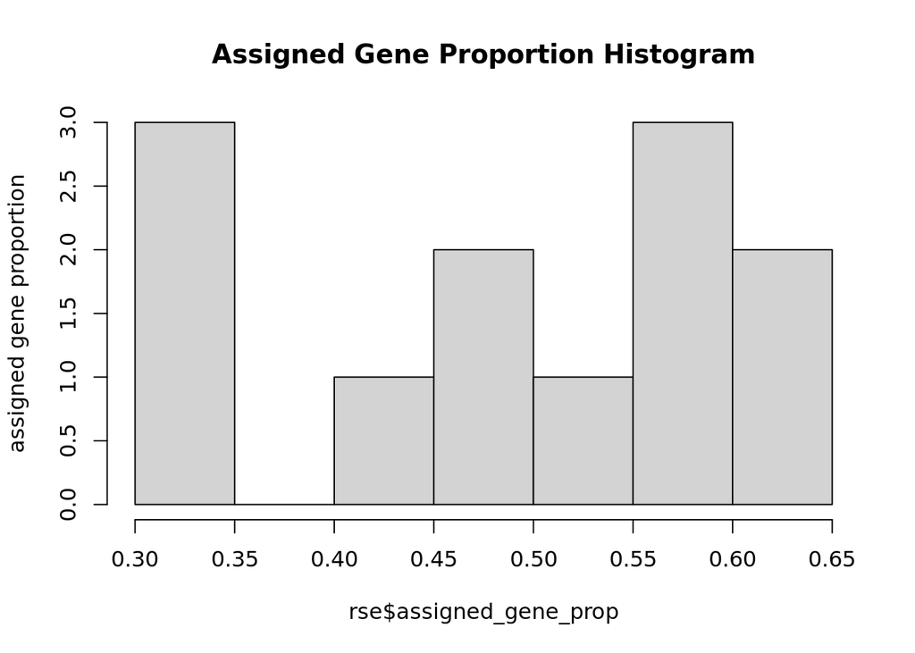

```r
#create gene prop column
rse$assigned_gene_prop <- rse$recount_qc.gene_fc_count_all.assigned/rse$recount_qc.gene_fc_count_all.total
#let's look at it in an histogram
hist(rse$assigned_gene_prop, main='Assigned Gene Proportion Histogram', ylab='assigned gene proportion')
```

```r
#use summary
summary(rse$assigned_gene_prop)
```

```
##    Min. 1st Qu.  Median    Mean 3rd Qu.    Max.
##  0.3072  0.4155  0.5175  0.4891  0.5697  0.6430
```

```r
# save an 'original' version
rse_unfiltered<-rse
#get rid of first quartil
rse <- rse[, rse$assigned_gene_prop > 0.4155]
```

Let’s start thinking about the experimental design.

```r
#we're interested in the following variables
table(rse$sra_attribute.cell_type)
```

```
##
##               Asthma human bronchial epithelium
##                                               2
## BEAS-2B immortalized human bronchial epithelium
##                                               3
##               Normal human bronchial epithelium
##                                               4
```

```r
table(rse$sra_attribute.treatment)
```

```
##
##            Calcitriol Calcitriol + Poly I:C              Poly I:C
##                     2                     2                     3
##  Sham (culture media)
##                     2
```

Let’s look at sample variation according to different categories.

```r
with(colData(rse), tapply(assigned_gene_prop, sra_attribute.treatment, summary))
```

```
## $Calcitriol
##    Min. 1st Qu.  Median    Mean 3rd Qu.    Max.
##  0.5392  0.5457  0.5522  0.5522  0.5587  0.5652
##
## $`Calcitriol + Poly I:C`
##    Min. 1st Qu.  Median    Mean 3rd Qu.    Max.
##  0.5530  0.5606  0.5682  0.5682  0.5758  0.5834
##
## $`Poly I:C`
##    Min. 1st Qu.  Median    Mean 3rd Qu.    Max.
##  0.4391  0.4674  0.4958  0.5259  0.5694  0.6430
##
## $`Sham (culture media)`
##    Min. 1st Qu.  Median    Mean 3rd Qu.    Max.
##  0.4600  0.4996  0.5392  0.5392  0.5788  0.6185
```

```r
with(colData(rse), tapply(assigned_gene_prop, sra_attribute.cell_type, summary))
```

```
## $`Asthma human bronchial epithelium`
##    Min. 1st Qu.  Median    Mean 3rd Qu.    Max.
##  0.4391  0.4443  0.4495  0.4495  0.4548  0.4600
##
## $`BEAS-2B immortalized human bronchial epithelium`
##    Min. 1st Qu.  Median    Mean 3rd Qu.    Max.
##  0.4958  0.5175  0.5392  0.5395  0.5613  0.5834
##
## $`Normal human bronchial epithelium`
##    Min. 1st Qu.  Median    Mean 3rd Qu.    Max.
##  0.5530  0.5621  0.5918  0.5949  0.6246  0.6430
```

Knowing how mean gene expression behaves is important when determining useful data.

```r
gene_means <- rowMeans(assay(rse, "counts"))
summary(gene_means)
```

```
##     Min.  1st Qu.   Median     Mean  3rd Qu.     Max.
##      0.0      0.0      0.4    378.4     39.1 563962.0
```

```r
#we also remove those with means under the first quartile
rse<-rse[gene_means > 0, ]
(dim(rse)/dim(rse_unfiltered))[1]*100
```

```
## [1] 61.47112
```

## Normalization

Before being able to conclude anything regarding differential expression, data must be normalized to prevent inherent bias.

```r
#normalize
norm <- DGEList( counts = assay(rse, "counts"),genes = rowData(rse))
norm <- calcNormFactors(norm)
```

As a final change we’ll rename some categories and add them as a new column for easier access and interpretation.

```r
rse$treatment<-rse$sra_attribute.treatment
rse$cell_type<-rse$sra_attribute.cell_type
```

## Differential Expression

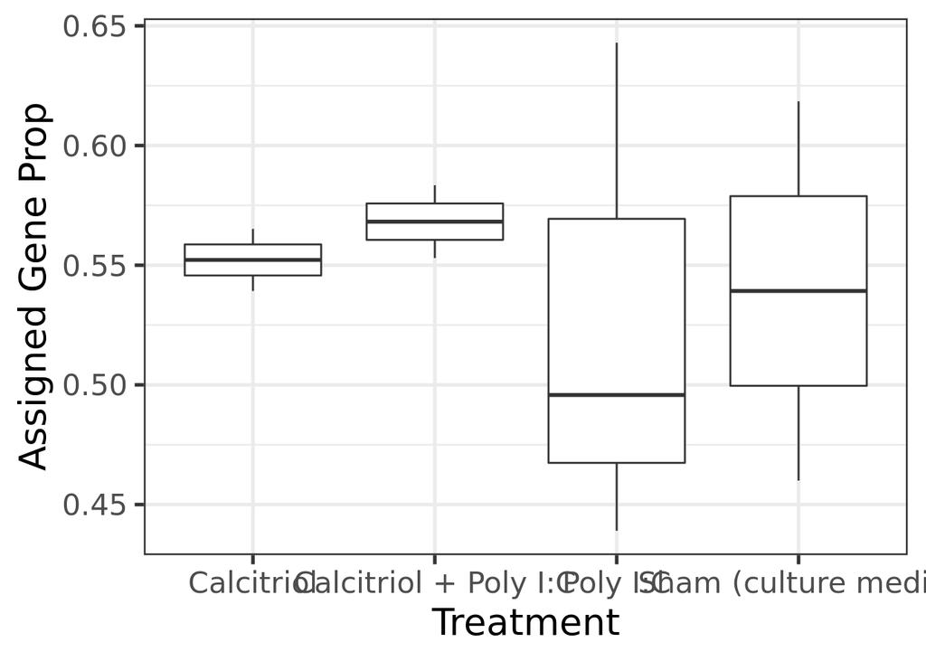

```r
#import
library("ggplot2")
#plot in boxplot
ggplot(as.data.frame(colData(rse)), aes(y = assigned_gene_prop, x = sra_attribute.treatment)) +
    geom_boxplot() +
    theme_bw(base_size = 20) +
    ylab("Assigned Gene Prop") +
    xlab("Treatment")
```

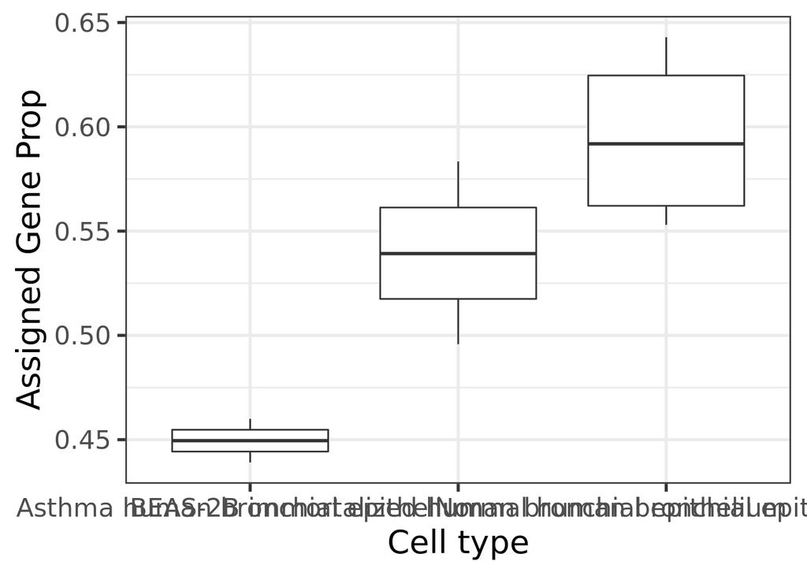

```r
ggplot(as.data.frame(colData(rse)), aes(y = assigned_gene_prop, x = sra_attribute.cell_type)) +
    geom_boxplot() +
    theme_bw(base_size = 20) +
    ylab("Assigned Gene Prop") +
    xlab("Cell type")
```

```r
#model
model <- model.matrix(~ treatment + cell_type + assigned_gene_prop, data = colData(rse) )
colnames(model)
```

```
## [1] "(Intercept)"
## [2] "treatmentCalcitriol + Poly I:C"
## [3] "treatmentPoly I:C"
## [4] "treatmentSham (culture media)"
## [5] "cell_typeBEAS-2B immortalized human bronchial epithelium"
## [6] "cell_typeNormal human bronchial epithelium"
## [7] "assigned_gene_prop"
```

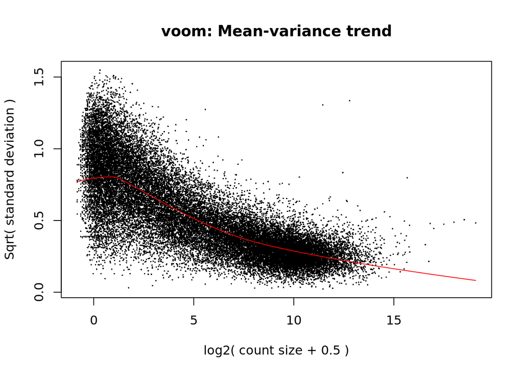

```r
library("limma")
vGene <- voom(norm, model, plot = TRUE)
```

```r
eb_results <- eBayes(lmFit(vGene))

de_results <- topTable(
    eb_results,
    coef = 2,
    number = nrow(rse),
    sort.by = "none"
)
dim(de_results)
```

```
## [1] 39253    16
```

```r
head(de_results)
```

[output not shown]

```r
table(de_results$adj.P.Val < 0.05)
```

```
##
## FALSE  TRUE
## 39243    10
```

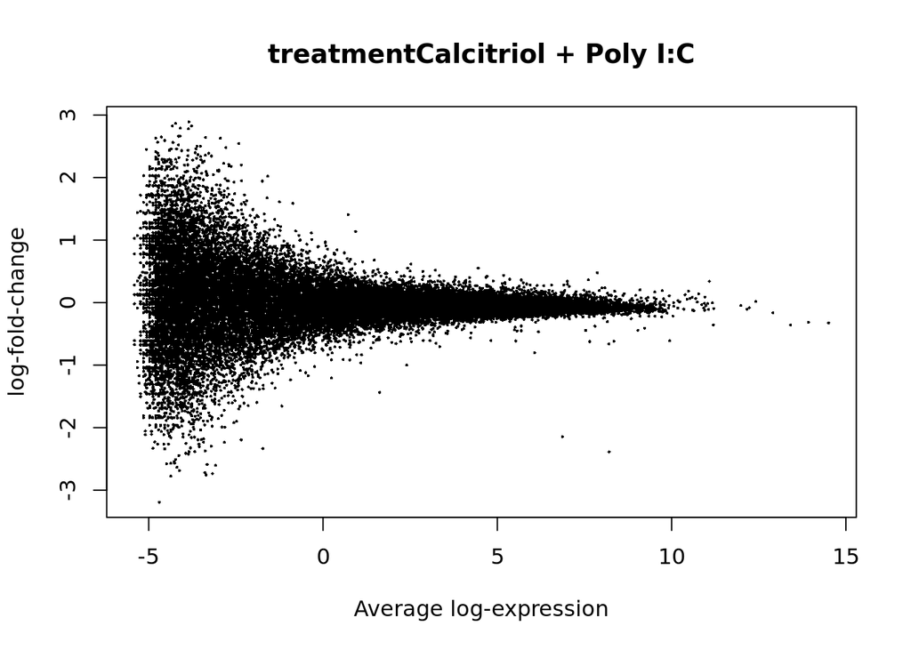

```r
plotMA(eb_results, coef = 2)
```

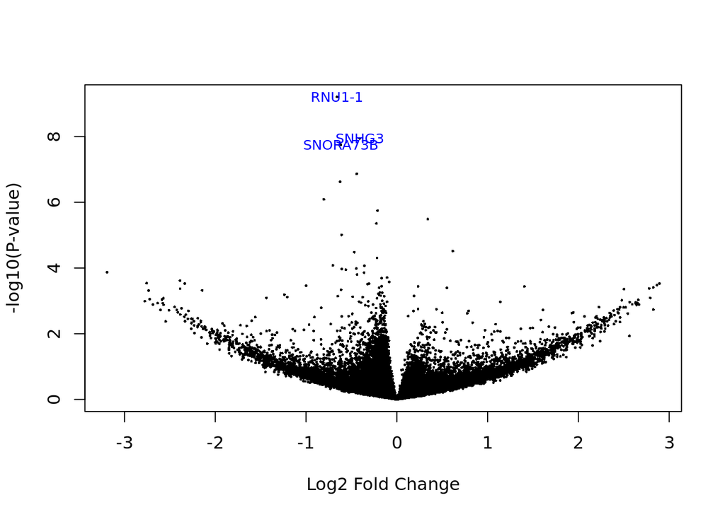

```r
volcanoplot(eb_results, coef = 2, highlight = 3, names = de_results$gene_name)
```

```r
highlighted<-c('RNU1-1','SNORA73B', 'SNHG3')
de_results[de_results$gene_name %in% highlighted, ]
```

```
##                    source type score phase           gene_id      gene_type
## ENSG00000206652.1 ENSEMBL gene   164    NA ENSG00000206652.1          snRNA
## ENSG00000200087.1 ENSEMBL gene   204    NA ENSG00000200087.1         snoRNA
## ENSG00000242125.3  HAVANA gene  4088    NA ENSG00000242125.3 sense_intronic
##                   gene_name level          havana_gene               tag
## ENSG00000206652.1    RNU1-1     3                 <NA>              <NA>
## ENSG00000200087.1  SNORA73B     3                 <NA>              <NA>
## ENSG00000242125.3     SNHG3     2 OTTHUMG00000003657.2 overlapping_locus
##                        logFC  AveExpr          t      P.Value    adj.P.Val
## ENSG00000206652.1 -0.6591294 8.202433 -10.617020 6.202551e-10 2.434687e-05
## ENSG00000200087.1 -0.6179043 8.345344  -8.752880 1.780025e-08 2.329044e-04
## ENSG00000242125.3 -0.4099519 9.225454  -8.987593 1.139346e-08 2.236138e-04
##                           B
## ENSG00000206652.1 12.897553
## ENSG00000200087.1  9.490609
## ENSG00000242125.3  9.802616
```

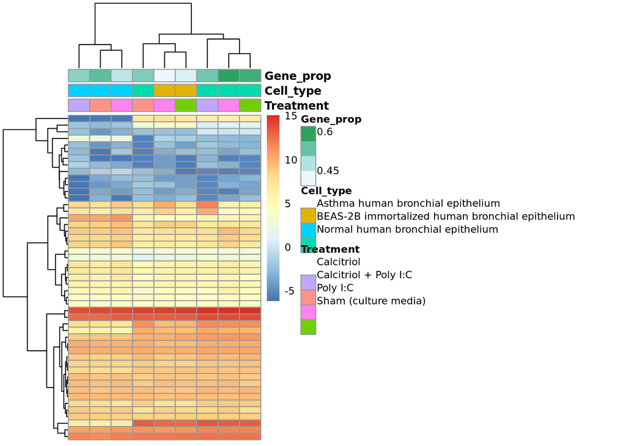

```r
# Use genes with most significant expr changes
exprs_heatmap <- vGene$E[rank(de_results$adj.P.Val) <= 50, ]

# create data frame
dataf <- as.data.frame(colData(rse)[, c("treatment", "cell_type", "assigned_gene_prop")])
colnames(dataf) <- c("Treatment", "Cell_type", "Gene_prop")

## pheatmap
library("pheatmap")
pheatmap(
    exprs_heatmap,
    cluster_rows = TRUE,
    cluster_cols = TRUE,
    show_rownames = FALSE,
    show_colnames = FALSE,
    cex = 0.9,
    annotation_col = dataf
)
```

```r
# color is pretty
library("RColorBrewer")

treat <- dataf$Treatment
levels(treat) <- brewer.pal(nlevels(treat), "Set1")
cellt <- dataf$Cell_type
levels(cellt) <- brewer.pal(nlevels(cellt), "Dark2")
```

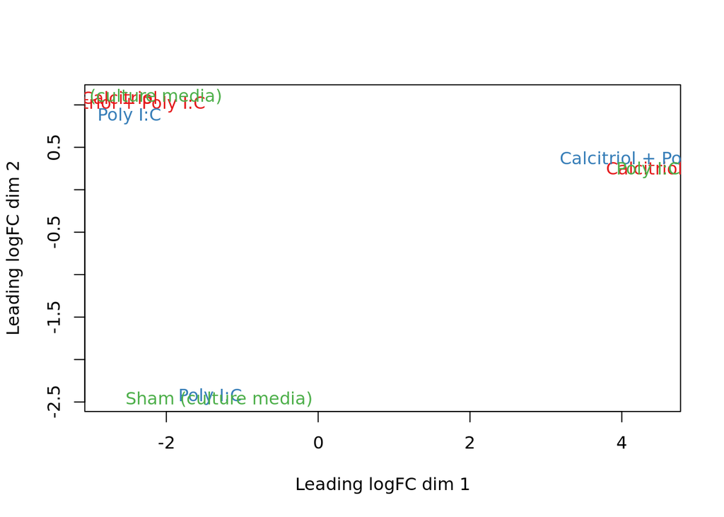

```r
plotMDS(vGene$E, labels = dataf$Treatment , col = levels(treat))
```

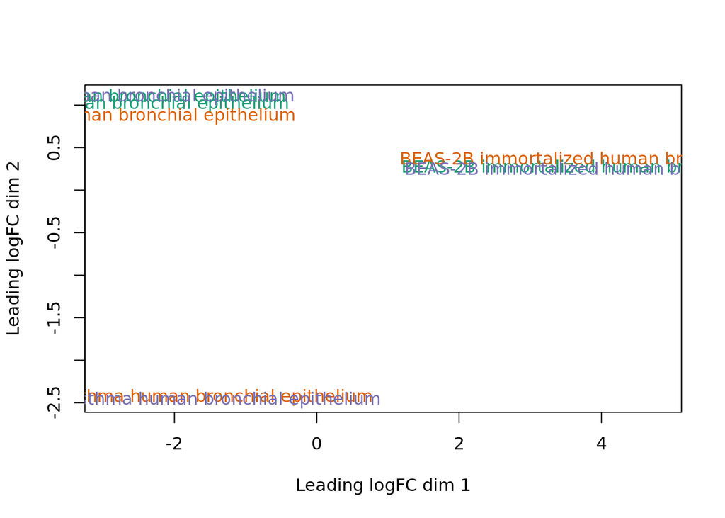

```r
plotMDS(vGene$E, labels = dataf$Cell_type , col = levels(cellt))
```

## Conclusion

Despite what was previously described, it’s importamt to keep in mind that the small data size may prompt inadequate conclusions. Perhaps a comparison of only the genes involved in the target pathway could yield clearer, gene-specific observations.